# Supplements

### 1. Information Gain

##### 1.1 load the data

```r
df1 <- read.csv('df1.csv')
df2 <- read.csv('df2.csv')
library(caTools)
set.seed(696)
split1 = sample.split(df1$credit, SplitRatio = 0.5)
training <- subset(df1, split1 == TRUE)
```

##### 1.2 calculating entropy of the parent, i.e entropy of the credit (response variable)

```r
prop_credit <- prop.table(table(training$credit))
parent_entropy <- - sum((prop_credit * log2(prop_credit)))
parent_entropy
```

```
## [1] 0.9790982
```

##### 1.3 calculating entropy of the children, i.e. entropy of other predictor variables

**a. categorical variables**

```r
# calculate the proportions of each value of categorical variables against 'credit'
prop_elements <- function(x){
  prop.table(table(training[[x]], training$credit) + 1e-6, margin = 1)
}
```

```r
# calculate the entropy of categorical variables as the children of 'credit'
categorical_child_entropy <- function(x){
  prop_elements <- prop.table(table(training[[x]], training$credit) + 1e-6, margin = 1)
  sum(prop.table(table(training[[x]]))*rowSums(-prop_elements(x)*log2(prop_elements(x))))
}
for(i in 2:10){
  cat('\nEntropy of', names(training[i]), ':', categorical_child_entropy(i))
}
```

```
##
## Entropy of checking : 0.9565311
## Entropy of history : 0.7448066
## Entropy of loan_reason : 0.9514728
## Entropy of saving : 0.9660019
## Entropy of employment : 0.934588
## Entropy of status : 0.9736379
## Entropy of housing : 0.9735514
## Entropy of job : 0.9675935
## Entropy of foreign : 0.9785001
```

**b. numeric variables**

choosing the best splits for numeric variables, i.e. finding the split that the numeric variable has the lowest entropy

```r
library(tree)
```

*b.1 months*

```r
# building a simple tree to choose a split
# in which the information gain is maxisimised for that split
tree_month <- tree(training$credit ~ training$months)
tree_month  # choosing the split at 26.5
```

```
## node), split, n, deviance, yval, (yprob)
##       * denotes terminal node
##
## 1) root 318 431.6 Good ( 0.4151 0.5849 )
##   2) training$months < 26.5 224 295.3 Good ( 0.3705 0.6295 ) *
##   3) training$months > 26.5 94 130.1 Bad ( 0.5213 0.4787 ) *
```

split the data into two groups, i.e. one group having greater than 26.5 months, the other less than 26.5

```r
upper_months <- training$credit[training$months > 26.5]
lower_months <- training$credit[training$months < 26.5]
prop_upper_months <- length(upper_months)/length(training$credit)
prop_lower_months <- length(lower_months)/length(training$credit)
upper_cut <- table(upper_months)
lower_cut <- table(lower_months)
# calculate proportions for each group
c <- rbind(upper_cut, lower_cut)
d <- prop.table(c, margin = 1)
d
```

```
##                 Bad      Good
## upper_cut 0.5212766 0.4787234
## lower_cut 0.3705357 0.6294643
```

```r
# calculate the entropy for months at the split of 26.5
entropy_months = prop_upper_months * rowSums(-d*log2(d))[[1]] +
  prop_lower_months * rowSums(-d*log2(d))[[2]]
cat('\nEntropy of', names(training[11]), ':', entropy_months)
```

```
##
## Entropy of months : 0.9651562
```

*b.2 residence & age*

building a simple tree to choose a split in which the information gain is maxisimised for that split

```r
tree_residence <- tree(training$credit ~ training$residence)
tree_age <- tree(training$credit ~ training$age)
```

```r
# examine the trees
tree_residence    # there is only root which does not grow its subsequent branches
```

```
## node), split, n, deviance, yval, (yprob)
##       * denotes terminal node
##
## 1) root 318 431.6 Good ( 0.4151 0.5849 ) *
```

```r
tree_age          # there is only root which does not grow its subsequent branches
```

```
## node), split, n, deviance, yval, (yprob)
##       * denotes terminal node
##
## 1) root 318 431.6 Good ( 0.4151 0.5849 ) *
```

conclusion: the trees could not choose splits for those two variables, it implies that the entropies of those two children are greater than their parent, i.e. credit. Therefore, the trees decide not to split when the information gain (parent’s entropy - children’s entropy) is not positive

##### 1.4 calculating information gain

```r
# create vector info_gain
info_gain <- c()
for(i in 2:13){
  if(i<=10){
    info_gain <- c(info_gain, parent_entropy - categorical_child_entropy(i))
  }else if(i == 11){
    info_gain <- c(info_gain, parent_entropy - entropy_months)
  }else{
    info_gain <- c(info_gain, 0)
  }
}
# create vector colnames, i.e. names for the correspondong info_gain values
colnames <- c()
for(i in 2:13){
  colnames <- c(colnames, names(training[i]))
}
info_gain_matrix <- matrix(info_gain, dimnames = list(colnames))
info_gain_matrix
```

```
##                     [,1]
## checking    0.0225670649
## history     0.2342915271
## loan_reason 0.0276254086
## saving      0.0130962664
## employment  0.0445101736
## status      0.0054602480
## housing     0.0055467712
## job         0.0115047117
## foreign     0.0005981155
## months      0.0139419740
## residence   0.0000000000
## age         0.0000000000
```

##### 1.5 checking the split for single-predictor tree models with response variable “credit”

```r
tree(training$credit ~ training$checking)       # split available for "checking" variable
```

```
## node), split, n, deviance, yval, (yprob)
##       * denotes terminal node
##
## 1) root 318 431.6 Good ( 0.4151 0.5849 )
##   2) training$checking: Low,No Balance 204 282.3 Good ( 0.4755 0.5245 ) *
##   3) training$checking: High,No Acct 114 140.6 Good ( 0.3070 0.6930 ) *
```

```r
tree(training$credit ~ training$history)        # split available for "history" variable
```

```
## node), split, n, deviance, yval, (yprob)
##       * denotes terminal node
##
## 1) root 318 431.60 Good ( 0.4151 0.5849 )
##   2) training$history: Critical 37   0.00 Bad ( 1.0000 0.0000 ) *
##   3) training$history: All Paid,Bank Paid,Current,Delay 281 359.50 Good ( 0.3381 0.6619 )
##     6) training$history: Current,Delay 203 276.70 Good ( 0.4236 0.5764 ) *
##     7) training$history: All Paid,Bank Paid 78  55.79 Good ( 0.1154 0.8846 ) *
```

```r
tree(training$credit ~ training$loan_reason)    # split available for "loan_reason" variable
```

```
## node), split, n, deviance, yval, (yprob)
##       * denotes terminal node
##
## 1) root 318 431.6 Good ( 0.4151 0.5849 )
##   2) training$loan_reason: Car New,Education,Furniture 166 229.9 Good ( 0.4819 0.5181 ) *
##   3) training$loan_reason: Business,Car Used,Large Appliance,Other,Repairs,Retraining,Small Appliance 152 195.3 Good ( 0.3421 0.6579 ) *
```

```r
tree(training$credit ~ training$saving)         # split unavailable for "saving" variable
```

```
## node), split, n, deviance, yval, (yprob)
##       * denotes terminal node
##
## 1) root 318 431.6 Good ( 0.4151 0.5849 ) *
```

```r
tree(training$credit ~ training$employment)     # split available for "employment" variable
```

```
## node), split, n, deviance, yval, (yprob)
##       * denotes terminal node
##
## 1) root 318 431.60 Good ( 0.4151 0.5849 )
##   2) training$employment: Long,Retired,Short,Unemployed,Very Short 253 349.30 Good ( 0.4625 0.5375 )
##     4) training$employment: Retired,Short 92 126.00 Bad ( 0.5652 0.4348 ) *
##     5) training$employment: Long,Unemployed,Very Short 161 217.20 Good ( 0.4037 0.5963 ) *
##   3) training$employment: Medium 65  70.23 Good ( 0.2308 0.7692 ) *
```

```r
tree(training$credit ~ training$status)         # split unavailable for "status" variable
```

```
## node), split, n, deviance, yval, (yprob)
##       * denotes terminal node
##
## 1) root 318 431.6 Good ( 0.4151 0.5849 ) *
```

```r
tree(training$credit ~ training$housing)        # split unavailable for "housing" variable
```

```
## node), split, n, deviance, yval, (yprob)
##       * denotes terminal node
##
## 1) root 318 431.6 Good ( 0.4151 0.5849 ) *
```

```r
tree(training$credit ~ training$job)            # split unavailable for "job" variable
```

```
## node), split, n, deviance, yval, (yprob)
##       * denotes terminal node
##
## 1) root 318 431.6 Good ( 0.4151 0.5849 ) *
```

```r
tree(training$credit ~ training$foreign)        # split unavailable for "foreign" variable
```

```
## node), split, n, deviance, yval, (yprob)
##       * denotes terminal node
##
## 1) root 318 431.6 Good ( 0.4151 0.5849 ) *
```

```r
tree(training$credit ~ training$months)         # split available for "months" variable
```

```
## node), split, n, deviance, yval, (yprob)
##       * denotes terminal node
##
## 1) root 318 431.6 Good ( 0.4151 0.5849 )
##   2) training$months < 26.5 224 295.3 Good ( 0.3705 0.6295 ) *
##   3) training$months > 26.5 94 130.1 Bad ( 0.5213 0.4787 ) *
```

```r
tree(training$credit ~ training$residence)      # split unavailable for "residence" variable
```

```
## node), split, n, deviance, yval, (yprob)
##       * denotes terminal node
##
## 1) root 318 431.6 Good ( 0.4151 0.5849 ) *
```

```r
tree(training$credit ~ training$age)            # split unavailable for "age" variable
```

```
## node), split, n, deviance, yval, (yprob)
##       * denotes terminal node
##
## 1) root 318 431.6 Good ( 0.4151 0.5849 ) *
```

##### 1.6 Plotting Information Gain

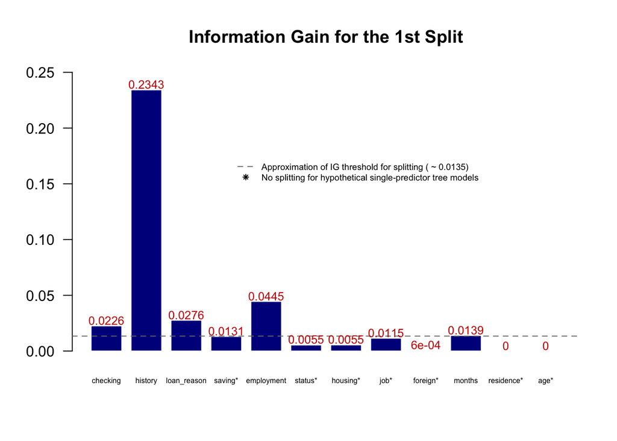

```r
# plot
bp <- barplot(info_gain_matrix,
              beside = T,
              names.arg = c('checking', 'history', 'loan_reason', 'saving*',
                            'employment', 'status*', 'housing*', 'job*',
                            'foreign*', 'months', 'residence*', 'age*'),
              las=1, cex.names=0.5,
              ylim = c(0, 0.25),
              space = 0.3,
              col= 'darkblue',border= 'white',
              main = 'Information Gain for the 1st Split')
abline(h = 0.0134, col = 'grey47', lty = 2)
text(bp,
     info_gain_matrix + 0.005,
     labels = round(info_gain_matrix, digits = 4),
     cex=0.8,
     col = 'red3')
legend(5, 0.175,
       legend = c('Approximation of IG threshold for splitting ( ~ 0.0135)',
                  'No splitting for hypothetical single-predictor tree models'),
       lty = c(2, NA),
       pch = c(NA, 8),
       col = c('grey47', 'black'),
       cex = 0.6,
       box.lty=0)
```

**CONCLUSION 10** The results show that decision tree will choose history as the root to have the first split. It also reflects the greedy search algorithm that the model try to maximise the information gain for every subsequent splits. Besides, in a hypothetical situation that there are tree models built from single preditors, it shows that the tree models decide not to split when the information gain is below the threshold level. The decision tree model is not only choosing the greatest information gain for the split but also having a criteria for stopping its braches growing.

### 2. ROC curve

##### 2.1 load the dataframe of models’ prediction probabilities

```r
models_prob <- read.csv('models_prob_predictions.csv')
head(models_prob)
```

```
##   tree_test_prob forest_test_prob gbm_test_prob numeric_credit_testing
## 1      0.6554622            0.660     0.5911804                      0
## 2      0.6554622            0.714     0.6012493                      0
## 3      0.6554622            0.656     0.5873926                      1
## 4      0.8846154            0.684     0.6170948                      1
## 5      0.3181818            0.506     0.5718736                      1
## 6      0.0000000            0.206     0.4783303                      0
```

##### 2.2 calculating sensitivity and specificity for the tree model on the testing set

```r
tree_prob_sort <- sort(models_prob$tree_test_prob)
tree_prob_no <- models_prob$tree_test_prob[models_prob$numeric_credit_testing == 0]
tree_prob_yes <- models_prob$tree_test_prob[models_prob$numeric_credit_testing == 1]
tree_sens <- c()         # create a new empty vector for the tree model's sensitivity
tree_spec <- c()         # create a new empty vector for the tree model's specificity
for(i in 1:nrow(models_prob)){
  tree_sens <- c(tree_sens, mean(tree_prob_yes >= tree_prob_sort[i]))
  tree_spec <- c(tree_spec, mean(tree_prob_no >= tree_prob_sort[i]))
}
```

##### 2.3 calculating sensitivity and specificity for the forest model on the testing set

```r
forest_prob_sort <- sort(models_prob$forest_test_prob)
forest_prob_no <- models_prob$forest_test_prob[models_prob$numeric_credit_testing == 0]
forest_prob_yes <- models_prob$forest_test_prob[models_prob$numeric_credit_testing == 1]
forest_sens <- c()       # create a new empty vector for the forest model's sensitivity
forest_spec <- c()       # create a new empty vector for the forest model's specificity
for(i in 1:nrow(models_prob)){
  forest_sens <- c(forest_sens, mean(forest_prob_yes >= forest_prob_sort[i]))
  forest_spec <- c(forest_spec, mean(forest_prob_no >= forest_prob_sort[i]))
}
```

##### 2.4 calculating sensitivity and specificity for the gbm model on the testing set

```r
gbm_prob_sort <- sort(models_prob$gbm_test_prob)
gbm_prob_no <- models_prob$gbm_test_prob[models_prob$numeric_credit_testing == 0]
gbm_prob_yes <- models_prob$gbm_test_prob[models_prob$numeric_credit_testing == 1]
gbm_sens <- c()           # create a new empty vector for the gbm model's sensitivity
gbm_spec <- c()           # create a new empty vector for the gbm model's specificity
for(i in 1:nrow(models_prob)){
  gbm_sens <- c(gbm_sens, mean(gbm_prob_yes >= gbm_prob_sort[i]))
  gbm_spec <- c(gbm_spec, mean(gbm_prob_no >= gbm_prob_sort[i]))
}
```

##### 2.5 plotting the ROC curve

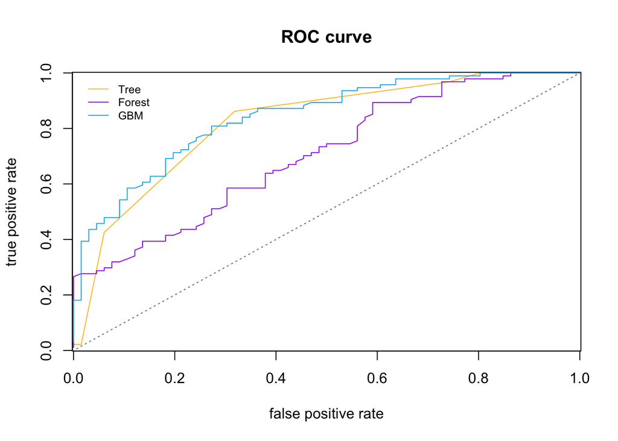

```r
plot(tree_spec, tree_sens,
     xlim = c(0.035, 0.965),
     ylim = c(0.035, 0.965),
     xlab = "false positive rate",
     ylab = "true positive rate",
     main = 'ROC curve',
     type = "l", col = 'goldenrod1')
lines(forest_spec, forest_sens, col = 'purple')
lines(gbm_spec, gbm_sens, col = 'deepskyblue2')
abline(0,1, col = 'grey47', lty =3)
legend(0.01,0.99,
       legend = c("Tree", "Forest", "GBM"),
       col = c("goldenrod1", "purple", "deepskyblue2"),
       lty =1, cex = 0.75, box.lty=0)
```

**CONCLUSION 11** The visualisation also validates the previous results on area under the curve for the three models. Random Forest has the smallest area under the curve. Meanwhile, GBM has the best and a slight better area under the curve than the tree model.